# Week 5: Finishing up Distributions and Correlations

DSI-EDA

09/16/2019

## Introduction

In weeks 3 and 4 of this course we learned how to visually inspect the distributions of univariate data using histograms and density plots. We also explored how boxplots can be useful for comparing across the distribution of variables across categories. We then learned about correlations and their corresponding scatterplots, and the ways in which we might investigate the strength of two variable’s covariance using Pearson’s Correlation Coefficient.

Today we will continue along these themes to wrap up this component of our course. First, I will show you a boxplot example that combines information from the `geom_point()` layer to present both boxplot and scatterplot information on a single graphic. On your own you will explore a graphic also commonly used to represent the shape of a distribution: the violin plot.

After this, we will revisit correlations by learning about correlograms (aka correlation matrices) and under what circumstances they might prove useful for our exploratory data analysis.

## Distributions, again!

Today, for illustrative purposes, we will work with data from the `gapminder` package. The dataset contains information on life expectancy, GDP per capita, and population by country from 1952 to 2007 in increments of 5 years.

```r
library(gapminder)
library(ggplot2)
library(dplyr)
head(gapminder)
```

```
## # A tibble: 6 x 6
##   country     continent  year lifeExp      pop gdpPercap
##   <fct>       <fct>     <int>   <dbl>    <int>     <dbl>
## 1 Afghanistan Asia       1952    28.8  8425333      779.
## 2 Afghanistan Asia       1957    30.3  9240934      821.
## 3 Afghanistan Asia       1962    32.0 10267083      853.
## 4 Afghanistan Asia       1967    34.0 11537966      836.
## 5 Afghanistan Asia       1972    36.1 13079460      740.
## 6 Afghanistan Asia       1977    38.4 14880372      786.
```

```r
str(gapminder)
```

```
## Classes 'tbl_df', 'tbl' and 'data.frame':    1704 obs. of  6 variables:
##  $ country  : Factor w/ 142 levels "Afghanistan",..: 1 1 1 1 1 1 1 1 1 1 ...
##  $ continent: Factor w/ 5 levels "Africa","Americas",..: 3 3 3 3 3 3 3 3 3 3 ...
##  $ year     : int  1952 1957 1962 1967 1972 1977 1982 1987 1992 1997 ...
##  $ lifeExp  : num  28.8 30.3 32 34 36.1 ...
##  $ pop      : int  8425333 9240934 10267083 11537966 13079460 14880372 12881816 13867957 16317921 22227415 ...
##  $ gdpPercap: num  779 821 853 836 740 ...
```

```r
?gapminder

# let's rename it
df <- gapminder
```

Let’s examine the distribution of variables across groups using boxplots. Recall from last class:

- the box denotes the 25th and 75th percentile.
- the dark line within the box represents the median.
- the vertical lines reaching out from the box (a.k.a. the whiskers) denote the first quartile value minus 1.5 times the interquartile range and the third quartile value plus 1.5 times the interquartile range.
- Points outside the lines (whiskers) represent outliers!

Below, let’s explore the relationship between life expectancy and region. To do so, we specify x and y in the first layer and then add the `geom_boxplot()` layer.

```r
# together:
```

FYI we can flip the axes by using the coord_flip() command. This might increase legibility, particularly if some of your distributions exhibit high spread.

```r
# together:
```

We can overlap the boxplot with the original observations using the `geom_point()` geom. This illustrates how many observations are included in each group. Make sure to specify `outlier.shape = NA` within `geom_boxplot()` so that the outliers are not plotted in the `boxplot()` layer, which would be confusing since we are also plotting points using the `geom_point()` geom.

```r
# together:
```

```r
# together:
```

**Practice 1** Please try to re-create the plot shown on the projector in class.

Hints:

- our ‘x’ and ‘y’ stay the same in our first layer
- you need to look up a geom_ for ‘violin’ plots
- you will need to add points with colors and (perhaps) other adjustments

```r
# students:
```

## Correlation matrix

As mentioned in the introduction, there is another way in which we might want to visualize correlations. Specifically, it can be useful to look for patterns in our data across multiple variables, rather than relying on the more narrow specification of a bivariate scatterplot.

A correlogram (or correlation matrix) allows us to analyse the relationship between each pair of numeric variables in a dataset. It gives a quick overview of many relationships in the data.

```r
# together:
library(corrgram)
```

**Practice 2**

Look up the help file for `corrgram`, and change the arguments to produce different results. For example, change ‘order’ to NULL and upper.panel to NULL. What data does the plot automatically drop? What do the lines and colors mean?

```r
# students:
```

```r
devtools::install_github("kassambara/ggcorrplot")
library(ggcorrplot)
```

First, for the sake of illustration, let’s look at the correlation of an easy familiar dataset, `mtcars`. Below we simply create a matrix of all the variables in mtcars using the `cor()` function which we went over last time!

```r
# Correlation matrix
data(mtcars)
corr <- round(cor(mtcars), 1)
```

Below, we can make a basic correlogram using this same numeric information.

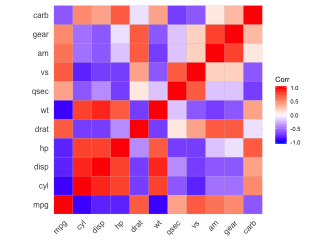

```r
# Plot
ggcorrplot(corr)
```

Just by reading a bit more about this function, we can make this much more visually useful. First, we can pick colors that are a bit easier on the eyes, and add our own colors in the `colors` argument. We can also choose `type="lower"` so that the graph only prints the lower triangle of correlations. Then we can change the plot to represent correlations as a circle conditioned on the size of the correlation using the `method="circle` argument. Try to do all of this below to reproduce the figure shown in class.

**Practice 3** Reproduce the graphic shown on the projector in class.

```r
# students
```

## References

- https://indrajeetpatil.github.io/ggstatsplot/articles/web_only/ggcorrmat.html
- https://www.statmethods.net/advgraphs/correlograms.html
- https://r-graph-gallery.com/correlogram.html
- http://r-statistics.co/Top50-Ggplot2-Visualizations-MasterList-R-Code.html#Correlogram